# Supplementary Note

Paul Hop

7/2020

Supplementary note corresponding to the manuscript: “Crossreactive probes on Illumina DNA methylation arrays: a large study on ALS shows that a cautionary approach is warranted in interpreting epigenome-wide association studies”.

## Data availability

The data used in this markdown can be downloaded from: https://doi.org/10.5281/zenodo.4110015. This script can be reproduced using the deposited data as follows:  
- Clone this repository: < git clone https://github.com/pjhop/dnamarray_crossreactivity.git >  
- Download the data (‘data.zip’) and place it in the ‘dnamarray_crossreactivity’ folder.  
- Unzip the data.zip folder

### Introduction

In the manuscript, we discuss several analytical checks that can aid in identifying cross-reactive probes. Here, we provide additional comments on these checks, discussing what they can and cannot tell about potential cross-reactivity issues. Moreover, we provide example R code for each check. For all scripts used in the manuscript, please visit: http://github.com/pjhop/dnamarray_crossreactivity. We wrapped several scripts into an R package which we also use in this document. The package is available at: http://github.com/pjhop/DNAmCrosshyb.

### 1. Off-target sequence matches

As suggested by previous studies, we recommend checking significant probes for off-target matches. The annotation files published by Zhou *et al.* (Zhou, Laird, and Shen 2017) provide a good starting point and can be downloaded here: https://zwdzwd.github.io/InfiniumAnnotation These files contain information on the number of off-target matches at different match lengths for each probe, and other useful information such as SNP-masking and probe-mapping quality (also see 7. Other issues).  
The authors recommend removing probes with one or more >=30bp off-target matches. However, we note that:

1. Sequence matches <30bp can be sufficient for detectable cross-hybridization. This is especially the case when those off-target matches measure similar DNA methylation levels, for example when the off-target matches are located in a repeat region. It is not straightforward to determine a exact cutoff. For example, many 20-25bp off-target matches may be more problematic (for example when a probes maps to a tandem repeat) than 1 30bp off-target match. We therefore recommend careful examination of the results, the other checks described in this document can help in identifying issues.
2. Imperfect matches off-target matches (i.e. allow mismatched INDELs) may lead to spurious associations. Additionally, by allowing a mismatch you also account for probes that may match an off-target region only when a SNP is present.
3. Genetic variation (especially structural variation such as tandem repeats) associated with the phenotype should be taken into account, since these are not taken into account by mapping probes to the reference genome.

#### Examples

Zhou annotations:

```r
# The MASK_sub30_copy column indicates that the probe has one or more >=30 bp off-target matches.
# The MASK_mapping column indicates that the probe has a low quality score
zhou_450k %>% dplyr::select(probeID, MASK_sub30_copy, MASK_mapping) %>%
  dplyr::filter(MASK_sub30_copy | MASK_mapping) %>%
  head()
```

```
## # A tibble: 6 x 3
##   probeID    MASK_sub30_copy MASK_mapping
##   <chr>      <lgl>           <lgl>
## 1 cg13869341 TRUE            TRUE
## 2 cg14008030 FALSE           TRUE
## 3 cg12045430 TRUE            TRUE
## 4 cg20826792 FALSE           TRUE
## 5 cg00381604 FALSE           TRUE
## 6 cg20253340 TRUE            TRUE
```

```r
# Map probes to the C9orf72 hexanucleotide repeat
repeat_sequence <- paste(rep("GGCCCC", 10), collapse="")

matches_c9 <- map_probes_sequence(sequence = repeat_sequence, next_base = "G", prev_base = "C",
                            array = "450k", min_width = 14,
                            max_width = 30, allow_indel = FALSE,
                            allow_mismatch = FALSE, step_size = 1,
                            use_Y = FALSE, methylation_status = "methylated")

data.frame(matches_c9 %>% dplyr::arrange(desc(width))) %>% head()
```

```
##        Probe start end  strand width sbe_site mismatch_pos max_mismatch_pos n_mismatch indel_pos width_incl_indel          sequence_bs
## 1 cg01587390     6  25 forward    20        T           NA               NA          0        NA               NA CGGTTTCGGTTTCGGTTTCG
## 2 cg01587390    12  31 forward    20        T           NA               NA          0        NA               NA CGGTTTCGGTTTCGGTTTCG
## 3 cg01587390    18  37 forward    20        T           NA               NA          0        NA               NA CGGTTTCGGTTTCGGTTTCG
## 4 cg01587390    24  43 forward    20        T           NA               NA          0        NA               NA CGGTTTCGGTTTCGGTTTCG
## 5 cg01587390    30  49 forward    20        T           NA               NA          0        NA               NA CGGTTTCGGTTTCGGTTTCG
## 6 cg01587390    36  55 forward    20        T           NA               NA          0        NA               NA CGGTTTCGGTTTCGGTTTCG
##          Type2 channel
## 1 I_Methylated     OOB
## 2 I_Methylated     OOB
## 3 I_Methylated     OOB
## 4 I_Methylated     OOB
## 5 I_Methylated     OOB
## 6 I_Methylated     OOB
```

Mapping probes to several disease-associated repeat-sequences:

```r
## run for several sequences, takes 30-40 minutes to run
sequences <- list(
  ATTCT = list(
    sequence = paste(rep("ATTCT", 15), collapse=""),
    prev_base = "T",
    next_base = "A"
  ),
  CAG = list(
    sequence = paste(rep("CAG", 20), collapse=""),
    prev_base = "G",
    next_base = "C"
  ),
  CTG = list(
    sequence = paste(rep("CTG", 20), collapse=""),
    prev_base = "G",
    next_base = "C"
  ),
  GAA = list(
    sequence = paste(rep("GAA", 20), collapse=""),
    prev_base = "A",
    next_base = "G"
  ),
  GCC = list(
    sequence = paste(rep("GCC", 20), collapse=""),
    prev_base = "C",
    next_base = "G"
  ),
  GCG = list(
    sequence = paste(rep("GCG", 20), collapse=""),
    next_base = "G",
    prev_base = "G"
  ),
  CGG = list(
    sequence = paste(rep("CGG", 20), collapse=""),
    next_base = "C",
    prev_base = "G"
)
)

run <- function(lst) {
  matches <- map_probes_sequence(sequence = lst[["sequence"]],
                                 next_base = lst[["next_base"]],
                                 prev_base = lst[["prev_base"]],
                      array = "450k", min_width = 14, max_width = 20,
                      allow_indel = TRUE,
                      allow_mismatch = TRUE, step_size = 1,
                      use_Y = TRUE)
  matches
}

matches_all <- purrr::map(sequences, .f = run)
names(matches_all) <- names(sequences)

# Check number of probes with >=14bp match for each sequence
# Check if filtered by Zhou et al.
zhou <- zhou_450k %>% dplyr::filter(MASK_sub30_copy | MASK_mapping)
make_overview <- function(sequence, matches_all) {
  check <- matches_all[[sequence]] %>% dplyr::filter(width >= 14)
  tibble(sequence = sequence, n_cr = dplyr::n_distinct(check$Probe),
         n_cr_zhou = sum(unique(check$Probe) %in% zhou$probeID))
}
overview <- purrr::map_df(names(matches_all), .f = make_overview, matches_all=matches_all)
overview
```

```
## # A tibble: 7 x 3
##   sequence  n_cr n_cr_zhou
##   <chr>    <int>     <int>
## 1 ATTCT        5         1
## 2 CAG        547        60
## 3 CTG        547        60
## 4 GAA          2         1
## 5 GCC        545        62
## 6 GCG        545        62
## 7 CGG        545        62
```

Mapping probes to the reference genome sequence, allowing mismatches and identifying off-target matches as small as 15bp. Bisulfite-converted reference genomes can be generated using the following scripts: https://github.com/pjhop/DNAmCrosshyb/blob/master/data-raw/bisulfite_convert_hg19.R and https://github.com/pjhop/DNAmCrosshyb/blob/master/data-raw/bisulfite_convert_hg38.R

Bisulfite-converted genomes in the R .rds file format are available at: https://doi.org/10.5281/zenodo.4088019

```r
# takes 30-40 minutes to run
probes <- c("cg00005164", "cg12344104", "cg25521682",
            "cg27660038", "cg20554142", "cg03890998",
            "cg00947801")
matches <- map_probes(probes,
                      path = "../data/genome_bs/hg19",
                      chromosomes = "all",
                      min_width = 15,
                      max_width = 20,
                      step_size = 5,
                      allow_mismatch = TRUE,
                      allow_INDEL = FALSE,
                      cores = 1
                     )
head(matches %>% dplyr::arrange(desc(width)) %>% data.frame())
```

```
##        Probe chr     start       end  strand next_base mismatch_pos Type2 width channel
## 1 cg12344104   1  62850945  62850964 forward         T            8    II    20    <NA>
## 2 cg12344104   1  90067416  90067435 forward         A           20    II    20    <NA>
## 3 cg12344104   1 154089442 154089461 forward         A            8    II    20    <NA>
## 4 cg12344104   1 178803544 178803563 forward         T            2    II    20    <NA>
## 5 cg25521682   1  40925714  40925733 forward         T            1    II    20    <NA>
## 6 cg25521682   1  61961145  61961164 forward         G            5    II    20    <NA>
```

Number of matches per probe:

```r
nr_matches <- get_nr_matches_per_probe(matches)
nr_matches
```

```
## # A tibble: 7 x 3
## # Groups:   Probe [7]
##   Probe        bp15   bp20
##   <chr>       <int>  <int>
## 1 cg00005164 179986 145507
## 2 cg00947801  98421   9790
## 3 cg03890998  79769   7686
## 4 cg12344104  60427    140
## 5 cg20554142 282145   9069
## 6 cg25521682   5810    138
## 7 cg27660038   4342     17
```

Overlap between off-target matches and repeat sequences:

```r
matches <- find_repeat_overlaps(matches, genome_build = "hg19", min_overlap = "any")
head(matches %>% data.frame())
```

```
##        Probe chr  start    end  strand next_base mismatch_pos Type2 width channel repeat_overlap
## 1 cg12344104   1  18881  18895 forward         Y            7    II    15    <NA>          FALSE
## 2 cg12344104   1  78306  78320 forward         T            8    II    15    <NA>           TRUE
## 3 cg12344104   1 333815 333829 forward         T            2    II    15    <NA>           TRUE
## 4 cg12344104   1 357053 357067 forward         A            5    II    15    <NA>           TRUE
## 5 cg12344104   1 457041 457055 forward         T            9    II    15    <NA>           TRUE
## 6 cg12344104   1 554449 554463 forward         T           10    II    15    <NA>          FALSE
```

### 2. Correlations among (near-)significant probes

Correlations among distal (near-)significant probes may be indicative of a technical issues.

#### Notes

1. Correlations may also be caused by biological factors. For example, a mutation in a gene that regulates DNA methylation, such as *DNMT3A*, may result in correlated differentially methylated CpG-sites. Moreover, confounding factors, such as batch effects and white blood cell composition, often result in groups of correlated probes. Although in the latter case correlations are not caused by cross-hybridization, they do often represent unwanted variation. In case of correlated probes, checking for sequence overlap will help in distinguishing between cross-hybridization-related correlation and other sources. The `get_probe_overlaps()` function in the `DNAmCrosshyb` package can be used to do this (see example in next section).

#### Example

Example of a correlation heatmap of the sites significantly associated with C9 status in our study. Note that 2 blocks of probes are correlated. The left upper corner includes the *trans* probes that we found to be cross-reactive (to the C9 repeat). The middle block consists of four probes that are all located within the same region (CpG island within the *C9orf72* gene).

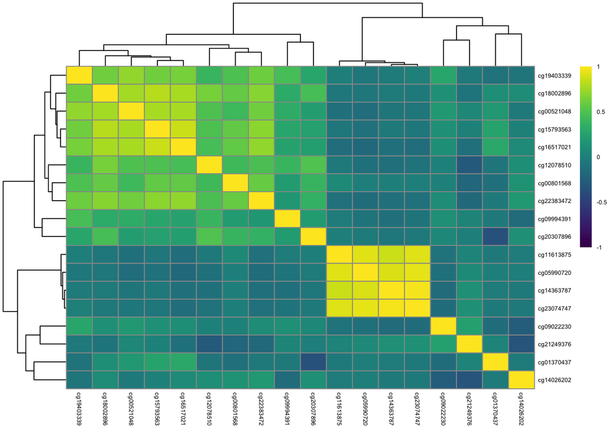

```r
# Heatmap
pal <- viridis::viridis(n = 200)
breaksList = seq(-1,1, by = 0.01)
heatmap <- pheatmap(cor(t(beta_sig), use = "complete.obs"),
                            color = pal,
                            breaks = breaksList,
                            width = 3, height = 4,
                            fontsize = 5)
```

### 3. Sequence overlap between (near-)significant probes

This point is related to the previous one: it is suspicious when significant sites share similar probe sequences.

#### Examples

The `get_probe_overlaps` function in the `DNAmCrosshyb` package can be used to check for overlapping 3’-subsequences in a set of probes. Here we apply this function to the probes that were significant in the C9 EWAS. We found that all *trans* probes that were correlated had a >=10bp overlap with each other.

```r
overlaps <- get_probe_overlaps(c(mlma_sig$Probe, mlma_oob_sig$Probe))
overlaps %>% dplyr::arrange(desc(overlaps$overlap))
```

```
## # A tibble: 1,892 x 6
##    Probe_Index Bead_Index              Probe_Target Bead_Target             overlap mismatch_pos
##    <chr>       <chr>                   <chr>        <chr>                     <int>        <int>
##  1 cg18002896  cg18002896_unmethylated cg24392382   cg24392382_unmethylated      25           13
##  2 cg24392382  cg24392382_unmethylated cg18002896   cg18002896_unmethylated      25           13
##  3 cg18002896  cg18002896_unmethylated cg16517021   cg16517021_unmethylated      24           16
##  4 cg16517021  cg16517021_unmethylated cg18002896   cg18002896_unmethylated      24           16
##  5 cg18002896  cg18002896_methylated   cg16517021   cg16517021_methylated        24           16
##  6 cg16517021  cg16517021_methylated   cg18002896   cg18002896_methylated        24           16
##  7 cg09994391  cg09994391_unmethylated cg01587390   cg01587390_unmethylated      21            9
##  8 cg12419491  cg12419491_unmethylated cg01587390   cg01587390_unmethylated      21            7
##  9 cg19403339  cg19403339_unmethylated cg00801568   cg00801568_unmethylated      21            9
## 10 cg19403339  cg19403339_unmethylated cg01587390   cg01587390_unmethylated      21           20
## # … with 1,882 more rows
```

Plot overlaps:

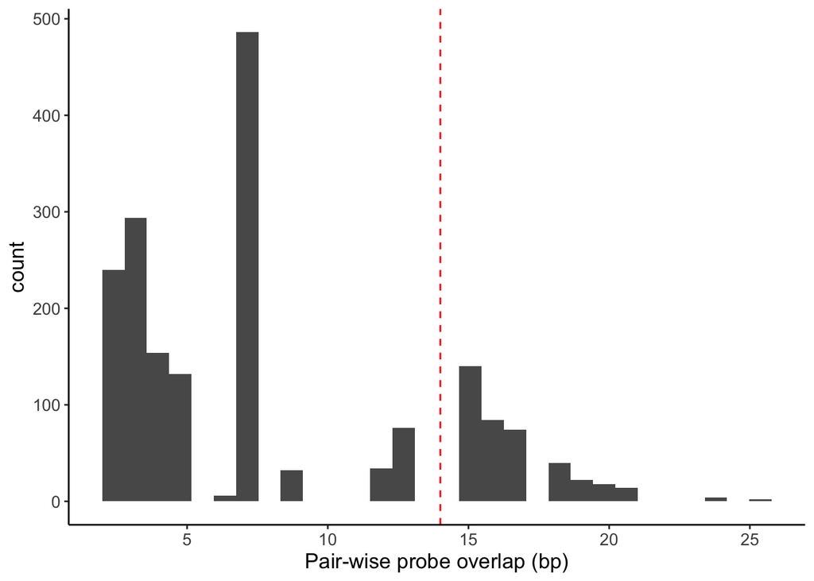

```r
ggplot(overlaps %>% filter(Probe_Index != Probe_Target),
       aes(x = overlap)) +
  geom_histogram() +
  theme_classic() +
  xlab("Pair-wise probe overlap (bp)") +
  geom_vline(xintercept = 14, linetype = "dashed", color = "red") +
  theme(text = element_text(size=13))
```

Check for each probe with how many other probes is has a >=10bp sequence overlap.

```r
check <- overlaps %>% dplyr::group_by(Bead_Index) %>% summarize(n = sum(overlap >= 10))
check %>% dplyr::filter(n > 1)
```

```
## # A tibble: 34 x 2
##    Bead_Index                  n
##    <chr>                   <int>
##  1 cg00521048_methylated      16
##  2 cg00521048_unmethylated    16
##  3 cg00801568_methylated      14
##  4 cg00801568_unmethylated    14
##  5 cg01370437_methylated      16
##  6 cg01370437_unmethylated    16
##  7 cg01587390_methylated      16
##  8 cg01587390_unmethylated    16
##  9 cg09994391_methylated      14
## 10 cg09994391_unmethylated    14
## # … with 24 more rows
```

### 4. Absence of regional effects at the target locus

We often expect that DNA methylation changes are not restricted to specific CpG-sites, but extend to surrounding regions. Therefore, a ‘lonely hit’, i.e. a signification association without any signal in the surrounding CpGs may indicate a technical issue. Instead of focusing on differentially methylated positions (DMPs), differentially methylated regions (DMRs) may be more biologically relevant and more robust to technical issues (Mill and Heijmans 2013)

#### Notes

1. Illumina DNA methylation arrays have a limited resolution, CpG-sites surrounding a target locus may not be measured. Therefore, identifying DMRs cannot completely replace DMPs, since a DMP may be reflective of a regional effect that is not measured and in certain cases DNA methylation changes may be restricted to only one or a feq sites.

#### Examples

The `locusplot()` function from the `DNAmCrossHyb` package can be used to plot a significant CpG-site and its neighbouring CpG-sites.

##### (Likely) True positive

First, we show a locus plot of the C9 island, which is very likely to be a true positive (found in different studies/tissues/techniques). Here, there is a regional effect, strengthening the evidence for a real biological effect:

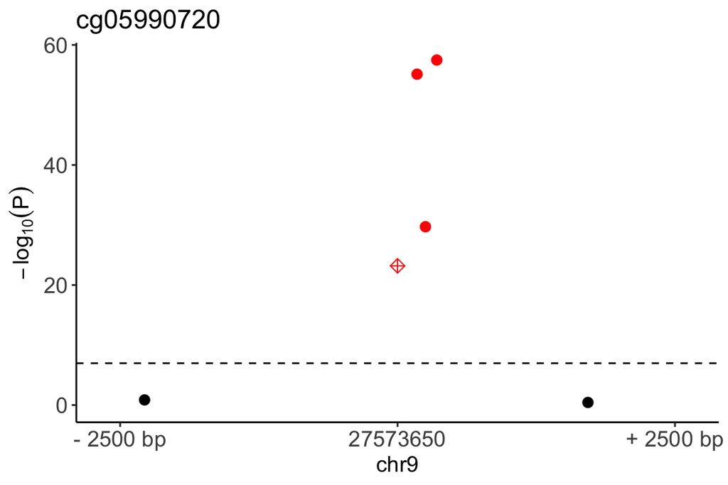

```r
# First an example of probes in the C9 island,
# these probes are very likely to be true positives (found in different # studies/tissues/techniques)
locusplot("cg05990720", stats = mlma,
          windowsize = 5000, significance_line = TRUE)
```

##### False positive

Here, we plot one of the significant *trans* probes. There is a very significant effect in one site, but no effect at all in the neighboring sites, which is a warning sign:

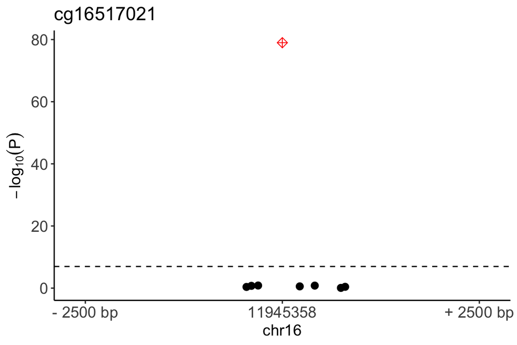

```r
# Example of a cross-reactive probe:
locusplot("cg16517021", stats = mlma,
          windowsize = 5000, significance_line = TRUE)
```

### 5. Associations in type I OOB channels

In the manuscript we show that several probes were significant in an EWAS on $\beta$-values derived from the out-of-band (OOB) channels. All these probes were probes with a partial match to the C9 repeat and were predicted to result in OOB sigal upon cross-hybridization. We thus found that inspecting OOB $\beta$-values can aid in identifying technical issues.

#### Notes

1. Associations in the OOB channels are in itself not problematic, since signals from these channels are not used in analyses. However, associations in OOB channels can help in identifying problematic sequences. In the *C9orf72* case, all OOB associations shared the same sequence, and thus helped pointing towards problematic probe sequences that also affected in-band associations.

#### Example

```r
# Using example data included in minfiData:
baseDir <- system.file("extdata", package="minfiData")
samplesheet <- read.metharray.sheet(baseDir)
```

```
## [1] "/Users/phop2/Library/R/3.5/library/minfiData/extdata/SampleSheet.csv"
```

```r
rgset <- read.metharray(samplesheet$Basename, extended=TRUE)

oob <- get_OOB(rgset, normalized = TRUE, keep = "both")
oob_betas <- oob$beta
oob_total_intensities <- oob$total
```

### 6. Associations between total intensity and the phenotype

An association between total signal intensity and the phenotype may indicate differences in the number of hybridization events. In that case, this indicates that there is either a copy number difference at the target locus, or that the probe cross-hybridizes to a region where there is a copy number difference.

#### Notes

1. Signal intensity effects may be confounded by signal saturation effects, that is, for some probes $\beta$-values near 1 or 0 (i.e. fully methylated, or fully unmethylated) tend to have lower total signal intensities than $\beta$-values near 0.5 (intermediate methylation) (Zhou et al. 2018). Thus, total signal intensity differences are especially informative when the direction of effect is opposite to what is to be expected based on signal saturation effects. For example, when $\beta$-values in the phenotype of interest are closer to 0.5, but total intensities are lower, this cannot be explained by signal saturation effects.

#### Examples

EWAS methods normally used on $\beta$-values (or M-values) can also be used to test for associations between total signal intensities and the phenotype of interest. Extracting total signal intensities:

```r
# Extract total signal intensities after normalization using dasen
rgset_dasen <- dasen(rgset)
total <- getCN(rgset_dasen)

# Extract total OOB signal intensities after normalization using dasen
# Using the function from DNAmCrosshyb
oob <- get_OOB(rgset, normalized = TRUE, keep = "both")
oob_total <- oob$total
```

### 7. Other issues

Finally, we note that in addition to cross-hybridization, other issues such as SNPs underlying the probe sequence could result in spurious associations. These issues are outside the scope of the current work, but we note that previously studies have considered these issues in detail (Zhou, Laird, and Shen 2017; Andrews et al. 2016). Example using population-specific SNP masking from Zhou *et al.*

```r
## Select SNP-containing probes based on European population:
zhou_450k_pop_EUR <- zhou_450k_pop %>%
  dplyr::filter(MASK_snp5_EUR)
```

Furthermore, one might want to filter probes that have a low mapping quality:

```r
zhou_450k %>% dplyr::filter(MASK_mapping) %>% dplyr::select(probeID, MASK_mapping) %>% head()
```

```
## # A tibble: 6 x 2
##   probeID    MASK_mapping
##   <chr>      <lgl>
## 1 cg13869341 TRUE
## 2 cg14008030 TRUE
## 3 cg12045430 TRUE
## 4 cg20826792 TRUE
## 5 cg00381604 TRUE
## 6 cg20253340 TRUE
```

### References

Andrews, Shan V., Christine Ladd-Acosta, Andrew P. Feinberg, Kasper D. Hansen, and M. Daniele Fallin. 2016. “‘Gap Hunting’ to Characterize Clustered Probe Signals in Illumina Methylation Array Data.” *Epigenetics & Chromatin* 9 (56). https://doi.org/10.1186/s13072-016-0107-z.

Mill, Jonathan, and Bastiaan T. Heijmans. 2013. “From Promises to Practical Strategies in Epigenetic Epidemiology.” *Nature Reviews Genetics* 14 (8): 585–94. http://www.nature.com/nrg/journal/v14/n8/abs/nrg3405.html.

Zhang, Futao, Wenhan Chen, Zhihong Zhu, Qian Zhang, Marta F. Nabais, Ting Qi, Ian J. Deary, et al. 2019. “OSCA: A Tool for Omic-Data-Based Complex Trait Analysis.” *Genome Biology* 20 (107). https://doi.org/10.1186/s13059-019-1718-z.

Zhou, Wanding, Peter W. Laird, and Hui Shen. 2017. “Comprehensive Characterization, Annotation and Innovative Use of Infinium DNA Methylation BeadChip Probes.” *Nucleic Acids Research* 45 (4): e22. https://doi.org/10.1093/nar/gkw967.

Zhou, Wanding, Timothy J Triche, Peter W Laird, and Hui Shen. 2018. “SeSAMe: Reducing Artifactual Detection of DNA Methylation by Infinium BeadChips in Genomic Deletions.” *Nucleic Acids Research* 46 (20): e123. https://doi.org/10.1093/nar/gky691.